# Un p-value complessivo per i test per livello di DHARMa

Come combinare i KS di `testCategorical()` e quale metodo scegliere

Data di Pubblicazione

23 ottobre 2026

# 1 Il problema

Con un predittore categoriale, `DHARMa::testCategorical()` esegue un test di Kolmogorov–Smirnov di uniformità sui residui scalati **separatamente per ogni livello**, corregge i p-value per test multipli e aggiunge un test di Levene sull’omogeneità della varianza tra livelli. Il risultato è un p-value per livello, mentre spesso serve **un solo p-value complessivo** per rispondere alla domanda: “i residui sono uniformi in *tutti* i livelli?”.

Formalmente vogliamo testare l’ipotesi nulla globale

$$H_0: \; H_{0,1} \cap H_{0,2} \cap \dots \cap H_{0,k},$$

dove $H_{0,j}$ dice che i residui del livello $j$ sono $U(0,1)$. Un risultato significativo dice che *almeno un* livello devia, non quale né di quanto.

## 1.1 Perché si possono combinare

I livelli contengono osservazioni disgiunte. Se il modello è corretto, i residui scalati di DHARMa sono (approssimativamente) i.i.d. $U(0,1)$, quindi i $k$ test KS sono **approssimativamente indipendenti**. È la stessa assunzione su cui si basa `testUniformity()` sull’intero campione. Questo permette di usare i metodi classici di combinazione, che assumono indipendenza.

**NotaUna cosa che hai già**

DHARMa riporta i p per livello già corretti per test multipli. Il **minimo dei p corretti** è già un test globale valido: con Holm o Bonferroni coincide con $\min(1, k \cdot p_{(1)})$, con Benjamini–Hochberg coincide con il test di Simes. È però conservativo e guarda essenzialmente solo il livello peggiore.

**AvvisoIl test di Levene non va combinato con i KS**

Il Levene usa gli stessi residui dei KS, quindi non è indipendente da loro. Va tenuto come secondo test, separato, e non inserito in una combinazione alla Fisher insieme ai KS.

# 2 I metodi

Siano $p_1, \dots, p_k$ i p-value dei KS per livello e $p_{(1)}$ il più piccolo.

**Fisher.** $X = -2\sum_j \ln p_j \sim \chi^2_{2k}$ sotto $H_0$. È dominato dai p piccoli: un solo livello con forte deviazione basta a renderlo significativo.

**Stouffer (pesato).** $Z = \sum_j w_j\, \Phi^{-1}(1-p_j) \big/ \sqrt{\sum_j w_j^2} \sim N(0,1)$. Media il segnale su tutti i livelli. Con $w_j = \sqrt{n_j}$ tiene conto di livelli di numerosità diversa.

**Tippett / Šidák.** $p = 1 - (1-p_{(1)})^k$. Guarda solo il livello peggiore. **Bonferroni** ($k\,p_{(1)}$) è la sua versione conservativa e valida anche sotto dipendenza arbitraria.

**Cauchy (ACAT).** $T = \sum_j w_j \tan\!\big[(0.5 - p_j)\pi\big]$ con $\sum_j w_j = 1$; il p-value è la coda destra di una Cauchy standard. È valido approssimativamente anche sotto dipendenza e si comporta in modo simile a Fisher/Tippett quando il segnale è concentrato.

**Harmonic mean p-value.** $\mathring{p} = \sum_j w_j \big/ \sum_j (w_j/p_j)$, robusto alla dipendenza. Richiede una calibrazione: usare il pacchetto `harmonicmeanp` invece della media armonica grezza.

## 2.1 Pro e contro

Tabella 1: Confronto dei metodi per ottenere un p-value complessivo

| Metodo | Potente quando | Pro | Contro |
| --- | --- | --- | --- |
| **Fisher** | La deviazione è forte in uno o pochi livelli | Default classico, semplice, buona potenza in molti scenari | Richiede indipendenza; un solo p estremo domina; non distingue la direzione |
| **Stouffer (pesato)** | La deviazione è lieve ma presente in tutti i livelli | Pesi naturali ($\sqrt{n_j}$); usa l’informazione di tutti i livelli | Meno potente se il problema è in un solo livello; richiede indipendenza |
| **Tippett / Šidák** | Un solo livello è problematico | Interpretazione immediata (“il livello peggiore”) | Ignora gli altri livelli; richiede indipendenza |
| **Bonferroni / min dei p corretti** | Un solo livello è problematico | Già disponibile da DHARMa; valido sotto qualunque dipendenza | Conservativo |
| **Cauchy (ACAT)** | Segnale concentrato; test dipendenti | Robusto alla dipendenza; calcolo banale | Approssimazione meno precisa per p non piccoli |
| **Harmonic mean p** | Segnale concentrato; test dipendenti | Robusto alla dipendenza; supporta il closed testing | Richiede la calibrazione del pacchetto dedicato |
| **Test diretti** (KS globale, Kruskal–Wallis, Levene) | Il tipo di deviazione è noto a priori | Un solo test mirato, spesso più potente | Rilevano solo il tipo di deviazione per cui sono costruiti |

Il metodo va scelto **prima** di guardare i risultati, in base al tipo di deviazione che ci si aspetta. Scegliere a posteriori il metodo con il p più piccolo invalida il test.

# 3 Esempio in R

## 3.1 Dati simulati

Un GLM di Poisson con un fattore a 5 livelli. Nel livello `E` i dati sono in realtà binomiali negativi (sovradispersi), quindi il modello è misspecificato solo lì.

```r
n_per <- 150
gruppo <- factor(rep(LETTERS[1:5], each = n_per))
x <- rnorm(length(gruppo))
eff_gruppo <- c(A = 0, B = 0.2, C = -0.2, D = 0.3, E = 0)
mu <- exp(0.8 + 0.4 * x + eff_gruppo[as.character(gruppo)])

y <- rpois(length(mu), mu)
in_E <- gruppo == "E"
y[in_E] <- rnbinom(sum(in_E), mu = mu[in_E], size = 2)

dati <- data.frame(y, x, gruppo)
fit <- glm(y ~ x + gruppo, family = poisson, data = dati)
```

## 3.2 Residui e test per livello

```r
res <- simulateResiduals(fit, n = 1000)
r <- res$scaledResiduals
```

L’output di `testCategorical()`, con il grafico per livello:

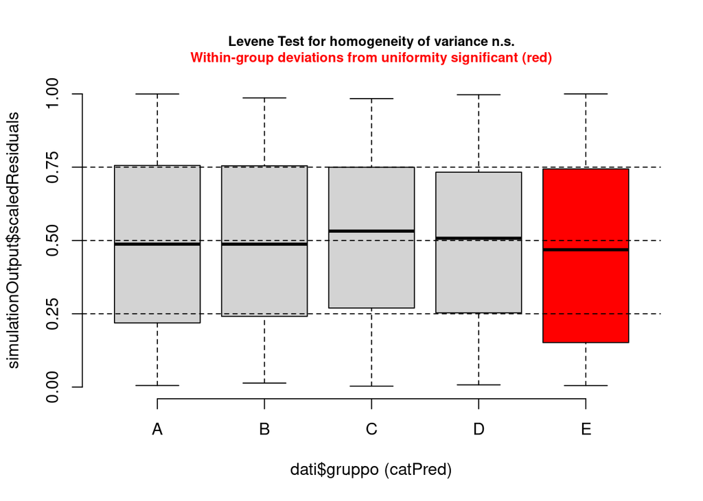

```r
tc <- testCategorical(res, catPred = dati$gruppo)
```

```r
str(tc, max.level = 2)
```

```
List of 2
 $ uniformity :List of 3
  ..$ details    :List of 5
  .. ..- attr(*, "dim")= int 5
  .. ..- attr(*, "dimnames")=List of 1
  .. ..- attr(*, "call")= language by.default(data = simulationOutput$scaledResiduals, INDICES = catPred,      FUN = ks.test, "punif", simplify = TRUE)
  .. ..- attr(*, "class")= chr "by"
  ..$ p.value    : num [1:5] 0.59428 0.94196 0.95514 0.97063 0.00874
  ..$ p.value.cor: num [1:5] 1 1 1 1 0.0437
 $ homogeneity:Classes 'anova' and 'data.frame':    2 obs. of  3 variables:
  ..$ Df     : int [1:2] 4 745
  ..$ F value: num [1:2] 2.17 NA
  ..$ Pr(>F) : num [1:2] 0.0705 NA
  ..- attr(*, "heading")= chr "Levene's Test for Homogeneity of Variance (center = median)"
```

Per non dipendere dalla struttura interna dell’oggetto restituito, ricalcoliamo i KS per livello direttamente. È lo stesso test che esegue DHARMa.

```r
ks_per_livello <- function(r, g) {
  sapply(split(r, g), function(ri) {
    suppressWarnings(ks.test(ri, "punif")$p.value)
  })
}

p_livelli <- ks_per_livello(r, dati$gruppo)
data.frame(
  livello = names(p_livelli),
  n = as.vector(table(dati$gruppo)),
  p = p_livelli,
  p_holm = p.adjust(p_livelli, method = "holm"),
  row.names = NULL
)
```

| livello | n | p | p_holm |
| --- | --- | --- | --- |
| A | 150 | 0.5942785 | 1.0000000 |
| B | 150 | 0.9419601 | 1.0000000 |
| C | 150 | 0.9551386 | 1.0000000 |
| D | 150 | 0.9706269 | 1.0000000 |
| E | 150 | 0.0087400 | 0.0436998 |

## 3.3 Combinazione

```r
combina_p <- function(p, w = rep(1, length(p))) {
  # evita log(0) e qnorm(1) = -Inf
  p <- pmin(pmax(p, .Machine$double.xmin), 1 - 1e-16)
  k <- length(p)
  wc <- w / sum(w)

  c(
    Fisher     = pchisq(-2 * sum(log(p)), df = 2 * k, lower.tail = FALSE),
    Stouffer   = pnorm(sum(w * qnorm(p, lower.tail = FALSE)) / sqrt(sum(w^2)),
                       lower.tail = FALSE),
    Tippett    = -expm1(k * log1p(-min(p))),   # 1 - (1 - p_min)^k, stabile
    Bonferroni = min(1, k * min(p)),
    Cauchy     = pcauchy(sum(wc * tan((0.5 - p) * pi)), lower.tail = FALSE)
  )
}

pesi <- sqrt(as.vector(table(dati$gruppo)))   # rilevante solo per Stouffer e Cauchy

data.frame(
  metodo = names(combina_p(p_livelli, pesi)),
  p_complessivo = signif(combina_p(p_livelli, pesi), 3),
  row.names = NULL
)
```

| metodo | p_complessivo |
| --- | --- |
| Fisher | 0.3740 |
| Stouffer | 0.9120 |
| Tippett | 0.0429 |
| Bonferroni | 0.0437 |
| Cauchy | 0.1180 |

Se si vuole aggiungere l’harmonic mean p-value calibrato:

```r
# install.packages("harmonicmeanp")
harmonicmeanp::p.hmp(p_livelli, w = pesi / sum(pesi), L = length(p_livelli))
```

## 3.4 Test diretti, per confronto

```r
dr <- data.frame(r = r, gruppo = dati$gruppo)

c(
  `KS globale (testUniformity)` = testUniformity(res, plot = FALSE)$p.value,
  `Kruskal-Wallis (posizione)`  = kruskal.test(r ~ gruppo, data = dr)$p.value,
  `Levene (dispersione)`        = car::leveneTest(r ~ gruppo, data = dr)[1, "Pr(>F)"]
)
```

```
KS globale (testUniformity)  Kruskal-Wallis (posizione)
                 0.35682919                  0.60001454
       Levene (dispersione)
                 0.07045854
```

Il Kruskal–Wallis rileva spostamenti di posizione dei residui tra livelli. Qui il fattore è nel modello, quindi le medie per livello sono stimate e il test non ha molto da trovare. Il problema simulato (sovradispersione in `E`) è di dispersione, ed è il tipo di deviazione a cui sono sensibili Levene e i KS per livello.

# 4 Quale metodo, in pratica: una piccola simulazione

Per vedere come cambia la potenza, simuliamo direttamente residui scalati per $k = 5$ livelli da 100 osservazioni in tre scenari:

- **H₀**: tutti i livelli uniformi (verifica del livello nominale del 5%).
- **Concentrato**: un solo livello ha residui a “U” (Beta(0.5, 0.5), tipico della sovradispersione), gli altri sono uniformi.
- **Diffuso**: tutti i livelli hanno una deviazione lieve (Beta(0.85, 0.85)).

```r
sim_potenza <- function(gen, B = 2000, k = 5, alpha = 0.05) {
  ris <- replicate(B, {
    rr <- lapply(seq_len(k), gen)
    p <- sapply(rr, function(ri) ks.test(ri, "punif")$p.value)
    c(combina_p(p), `KS globale` = ks.test(unlist(rr), "punif")$p.value)
  })
  rowMeans(ris < alpha)
}

n_sim <- 100
scenari <- list(
  `H0`          = function(j) runif(n_sim),
  `Concentrato` = function(j) if (j == 1) rbeta(n_sim, 0.5, 0.5) else runif(n_sim),
  `Diffuso`     = function(j) rbeta(n_sim, 0.85, 0.85)
)

tab_sim <- t(sapply(scenari, sim_potenza))
round(tab_sim, 3)
```

```
            Fisher Stouffer Tippett Bonferroni Cauchy KS globale
H0           0.038    0.036   0.038      0.037  0.038      0.052
Concentrato  0.337    0.205   0.435      0.431  0.416      0.134
Diffuso      0.108    0.121   0.086      0.085  0.093      0.200
```

Cosa ci si aspetta di vedere:

- Sotto **H₀** tutti i metodi rifiutano circa nel 5% dei casi: le combinazioni sono valide quando i livelli sono indipendenti.
- Con segnale **concentrato**, Fisher, Tippett, Bonferroni e Cauchy sono i più potenti. Stouffer e il KS globale perdono potenza perché il segnale di un solo livello viene diluito.
- Con segnale **diffuso**, Stouffer supera Fisher, e il KS globale sul campione intero (`testUniformity`) è tipicamente il più potente di tutti.

# 5 Raccomandazioni

1. **Default: Fisher sui KS per livello.** Una misspecificazione legata a un fattore riguarda di solito uno o pochi livelli, e Fisher è robusto in quel caso senza ignorare gli altri livelli.
2. **Se serve la massima semplicità** o si teme dipendenza tra i livelli (ad esempio effetti casuali condivisi tra livelli del fattore): il minimo dei p corretti già fornito da DHARMa (Bonferroni), oppure Cauchy.
3. **Se ci si aspetta una deviazione lieve e generalizzata**, il test giusto è probabilmente già `testUniformity()` sul campione intero. In alternativa Stouffer pesato.
4. **Riportare il Levene a parte**: risponde a una domanda diversa (dispersione diversa tra livelli) e non va combinato con i KS.
5. Come per tutti i test diagnostici di DHARMa, con campioni grandi un p piccolo non implica una deviazione rilevante: guardare sempre anche i grafici e la dimensione della deviazione.

# 6 Riferimenti

- Fisher, R. A. (1932). *Statistical Methods for Research Workers* (4ª ed.).
- Stouffer, S. A. et al. (1949). *The American Soldier*, Vol. 1.
- Tippett, L. H. C. (1931). *The Methods of Statistics*.
- Birnbaum, A. (1954). Combining independent tests of significance. *JASA*, 49, 559–574.
- Liu, Y., & Xie, J. (2020). Cauchy combination test. *JASA*, 115, 393–402.
- Wilson, D. J. (2019). The harmonic mean p-value for combining dependent tests. *PNAS*, 116, 1195–1200.
- Hartig, F. *DHARMa: Residual Diagnostics for Hierarchical Regression Models*. Pacchetto R.